# Inter‐specific aggression generates ant mosaics in canopies of primary tropical rainforest - Mottl - - Oikos - Wiley Online Library

[Oikos](https://onlinelibrary.wiley.com/journal/16000706)

[Early View](https://onlinelibrary.wiley.com/toc/16000706/0/0)

[figure not shown]

Research

Open Access

# Inter‐specific aggression generates ant mosaics in canopies of primary tropical rainforest

[Ondřej Mottl](https://onlinelibrary.wiley.com/action/doSearch?ContribAuthorStored=Mottl%2C+Ond%C5%99ej)

[Jacob Yombai](https://onlinelibrary.wiley.com/action/doSearch?ContribAuthorStored=Yombai%2C+Jacob)

[Vojtěch Novotný](https://onlinelibrary.wiley.com/action/doSearch?ContribAuthorStored=Novotn%C3%BD%2C+Vojt%C4%9Bch)

[Maurice Leponce](https://onlinelibrary.wiley.com/action/doSearch?ContribAuthorStored=Leponce%2C+Maurice)

[George D. Weiblen](https://onlinelibrary.wiley.com/action/doSearch?ContribAuthorStored=Weiblen%2C+George+D)

[Petr Klimeš](https://onlinelibrary.wiley.com/action/doSearch?ContribAuthorStored=Klime%C5%A1%2C+Petr)

First published: 23 April 2021

https://doi.org/10.1111/oik.08069

## Abstract

The ant mosaic is a concept of the non‐random spatial distribution of individual ant species in trees built upon the assumption of interspecific behavioural associations. However, colony identity and environmental variance may also play a role in species distribution. Here we assess the presence of ant mosaics in a primary forest ecosystem and whether they are structured by species' aggressive behaviours or by habitat filtering.

We sampled arboreal ants from vertically stratified baits exposed in 225 canopy trees in a 9‐ha plot of primary lowland forest in Papua New Guinea, the largest forest area surveyed to detect ant mosaics. We performed behavioural tests on conspecific ants from adjacent trees to determine the territories of individual colonies. We explored the environmental effects on the ant communities using information on the plot vegetation structure and topography. Furthermore, we created a novel statistical method to test for the community non‐random spatial structure across the plot via spatial randomisation of individual colony territories. Finally, we linked spatial segregation among the four most common species to experimentally assessed rates of interspecies aggression.

The ant communities comprised 57 species of highly variable abundance and vertical stratification. Ant community composition was spatially dependent, but it was not affected by tree species composition or canopy connectivity. Only local elevation had a significant but rather small effect. Individual colony territories ranged from one tree to 0.7 ha. Species were significantly over‐dispersed, with their territory overlap significantly reduced. The level of aggression between pairs of the four most common species was positively correlated with their spatial segregation. Our study demonstrates the presence of ant mosaics in tropical pristine forest, which are maintained by interspecific aggression rather than habitat filtering, with vegetation structure having a rather small and indirect effect, probably linked to microclimate variability.

## Introduction

The tropical rainforest, as a plant‐based ecosystem with the highest species diversity in terms of the number of vascular plants and insect species (Mittermeier et al. 2003), is an interesting but challenging system to study species spatial distributions and to reveal the relative contribution of the various influential factors. Indeed, tropical trees, as sedentary organisms, have served as model taxa of spatial ecology (Watt 1947, Kraft et al. 2008, Fibich et al. 2016, Vincent et al. 2018), like corals in coral reefs (Álvarez‐Noriega et al. 2018). This research has revealed that the spatial distribution of species is often a complex result of species–environment interactions (habitat filtering), interspecific interactions (competition, mutualism) and dispersal limitation, causing segregation or aggregation of species. While the distribution of trees has received considerable attention in the tropical primary forests (Condit et al. 2000, Fibich et al. 2016), spatially explicit analyses of insect distribution have rarely been conducted (Basset 1991) and the drivers of their spatial distribution in this ecosystem are much less understood.

One of the suitable insect taxa to study spatial distribution and co‐existence of species in tropical canopies are ants (Floren and Linsenmair 2000, Janda and Konecna 2011). In tropical rainforests, ants make up a significant part of the overall animal biomass, especially in the canopy (Floren and Linsenmair 1997, Davidson et al. 2003). Arboreal ants can be seen as mobile organisms that forage in all strata of tropical forests as their workers search for resources; but also, due to the semi‐permanent nature of ant nests, as sessile organisms that are moving over a longer temporal scale (Hölldobler and Wilson 1990), thus behaving somewhat similarly to plants. Spatially non‐overlapping territories of dominant ant species in the canopies were first described from an African cocoa plantation (Room 1971). The original ant mosaic theory postulates that arboreal ant communities are segregated by dominance hierarchies to dominant, subdominant and subordinate ants, resulting in a mixture of negative and positive interactions between ant species, or between colonies of the same species (Leston 1973, Blüthgen and Stork 2007).

Recently, research on ant mosaics has become more popular (332 results found when searching for ‘ant mosaic' on Web of Science between 2010 and 2020), while shifting its primary focus more towards the spatial segregation of territorially dominant arboreal ants (Blüthgen and Stork 2007, Sanders et al. 2007, Fayle et al. 2013, Dejean et al. 2019). We acknowledge this conceptual shift and, therefore, we will refer to the spatial segregation of dominant species when speaking about ant mosaics throughout the study. Unfortunately, this led to studies being plagued by inconsistent definitions of the ant mosaic and several methodological problems. Therefore, the presence of ant mosaics in pristine forests is still a topic of discussion, since some studies demonstrate the mosaic pattern (Dejean et al. 2000, 2015, 2019, Blüthgen and Stork 2007, Yusah et al. 2018, Law and Parr 2020, Leponce et al. 2021), while others do not find its presence (Floren and Linsenmair 2000, Fayle et al. 2013, Adams et al. 2017). The inability to draw a single conclusion is caused by several aspects. First, the original concept of an ant mosaic focused on the spatial segregation of territories of individual colonies or species in space, each often spanning several host trees (Majer 1972). However, most of the recent studies narrowed this concept to the study of segregation/aggregation of ant species within individual trees (Sanders et al. 2007, Fayle et al. 2013), between feeding resources in the individual branches (Blüthgen et al. 2004), or bird's nest ferns (Ellwood et al. 2016). This conceptual shift matters, as within‐tree segregation may be driven by different factors, such as microclimate, local food and nest‐site availability, while other factors may play a role at a broader scale. Second, to our best knowledge, all studies from tropical forests including the few plot‐based works (Dejean et al. 2015, 2019, Leponce et al. 2021), used statistical approaches that assume spatial independence of the samples (trees). This assumption is rarely the case for local studies, especially when plot based. Finally, previous studies have generally ignored the colony identity in the randomisation tests, although the canopy colonies are likely to occupy spatially exclusive territories (e.g. *Oecophylla smaragdina*; Hölldobler and Lumsden 1980). This may have an impact on the detection of a mosaic if the statistical test assumes that samples with the same species from neighbouring trees are independent, when in fact, they are the same colony.

Ant mosaics can be driven by the spatially non‐random distribution of food resources (extrafloral nectaries, honeydew; Blüthgen et al. 2000) and abiotic factors (e.g. nesting space, temperature). For abiotic factors, some studies indicate that limitation of nest sites (i.e. microhabitat diversity and availability) affects arboreal ant structure (Dejean et al. 2008, Fayle et al. 2013), but these studies were either conducted in a disturbed ecosystem or at a very small spatial scale (but see Plowman et al. 2020). The abiotic factor of temperature variability is also crucial for ants (Cerdá et al. 2013) and it could have an indirect effect on ant mosaics, affecting the behaviour of dominant species (Bestelmeyer 2000). Yet previous plot‐based studies do not include a formal analysis of the effects of biotic and abiotic factors, with the exception of recent studies that suggest that the taxonomic composition of trees and/or tree‐size variance contribute to ant mosaic distribution in primary forest plots, but ignore spatial dependency of the trees (Dejean et al. 2015, 2019, Plowman et al. 2020).

Even though the original experimental manipulations of dominant ants in cocoa plantations suggests that species' dominant behaviour plays the main role in shaping the distribution of arboreal ants (Majer 1976a, b1976b), there is no study from primary forest that experimentally tests for the role of competition (behaviour) and assesses the role of the various environmental factors. Moreover, that competition is the main mechanism to explain the non‐random spatial co‐occurrences in arboreal ants has been previously questioned (Ribas and Schoereder 2002, but see Camarota et al. 2016). The few experimental studies available to date from primary forests focus on the manipulation of communities from a single nesting microhabitat within trees (Fayle et al. 2015) or on baits exposed in the understorey (Davidson et al. 2007). There is especially a need for a unified methodology to study the spatial distribution of ant communities in a large forest plot and to develop an appropriate statistical test for ant mosaics (Leponce et al. 2021).

Here, we test for a non‐random spatial distribution of arboreal ant species and their colony territories across tree canopies, that is the presence of ant mosaics over a broader scale, in a lowland primary forest of Papua New Guinea (PNG). We mapped the spatial distribution of ants on 225 canopy trees within a 9 ha area of the forest, the largest such dataset for tropical tree canopies to date. We developed a new null model that randomises whole ant‐colony territories in space to test for overlap of territories. Further, we used experimental data on ant interspecific interactions and environmental data on vegetation structure with forest plot topography to disentangle the drivers of the observed spatial species distributions. We predict that: 1) there is a non‐random spatial distribution of arboreal ants in primary forest, with the species being over‐dispersed in forest tree canopies; 2) spatial structure of the ant community is driven primarily by species behaviour (competition) rather than by the environmental variability (habitat filtering); and 3) spatial segregation of species will correlate with their behavioural and morphological traits, particularly the level of aggression and body size.

## Material and methods

### Study site

All fieldwork was conducted in the CTFS‐ForestGEO research site (Anderson‐Teixeira et al. 2015) in lowland primary forest in the Wanang Conservation Area (Madang Province, PNG) between 14 of April and 23 of September 2016. The 50 ha CTFS Wanang plot has all trees with diameter at breast height (DBH) > 1 cm tagged, their DBH measured, identified to species level and coordinates mapped. The CTFS plot is structured into a grid of 20 × 20 m subplots; for details about all measured variables see Vincent et al. (2018). The plot has a total richness of 351 woody species, average basal area (BA) of 32.0 ± 13.7 m<sup>2</sup> ha<sup>−1</sup>, and average elevation of 131.3 ± 25.6 (min = 80.3, max = 189.7) m a.s.l. During our fieldwork, we measured mean daytime temperatures of between 23.5°C and 31.2°C, and mean precipitation of 381 mm per month. Seasonality in the region is low (McAlpine et al. 1983). We selected a 9 ha (300 × 300 m) area within the CTFS plot as our focal area for ant sampling.

We randomly selected 25 high canopy trees (defined as those with DBH ≥ 40 cm) in each hectare, 225 trees in total, from the 428 high canopy trees present, using the plant census from the CTFS plot database in 2009. In several cases, the tree was found dead in the field, in which case, we selected a nearby tree of a similar size. This approach ensured an intense and even cover of canopy within a large forest area whilst keeping sampling effort at a logistically feasible level and maximising the sampling effort over this broad scale (for map of all canopy trees see Supporting information).

We used the CTFS' data about individual tree DBH (in cm) and tree taxonomy (tree family/genus/species). In addition, we used for each subplot information about elevation (in m a.s.l.), slope of subplot (in %) and topography (convex/concave, calculated from height of surrounding subplots). Finally, we have estimated canopy connectivity for each tree as the number of neighbouring canopy trees that are connected to the sampled tree by their branches or lianas.

### Ant sampling

We used the slingshot bait‐line method for sampling the ants in the selected trees (for a detailed description, Leponce et al. 2021). Tuna honey baits (circa 5 g of canned tuna in oil and honey, mixed in 5:1 ratio, wrapped in a paper towel) were placed on a rope positioned along the tree trunk from the ground level to the canopy (i.e. from 0 to max 35 m depending on a tree height), with baits regularly spaced at 5 m intervals. The top bait was always touching the highest accessible branch in the canopy that we could loop a rope over. The number of baits and the position of the highest bait slightly varied depending on tree height and the accessibility of the top canopy branch (mean max. bait height = 20.0 ± 4.7 m). In total, 1127 baits were exposed to the ants across the 225 trees (mean bait number per tree = 5.0 ± 0.9). The rope was twisted around the tree so that all baits touched the tree trunk. We set up baits in the morning and left them exposed for 4–5 h, then carefully retrieved baits to ensure that individuals did not fall down, checked them for ant occupancy, and estimated the number of individuals of each ant species found on each bait. The ant individuals were firmly nested in the paper towel, so the number of ant individuals lost during retrieval is negligible (Leponce et al. 2021). We collected several individuals of each species in vials with absolute ethanol for later species confirmation. Baits were placed only in sunny weather without rain. Experiments interrupted by rain were repeated in sunny weather. All samples were sorted to the species/morphospecies level using a key (Bolton 1995), online images ([antweb.com](http://antweb.com/)), and the reference collection of New Guinea ants available at the Biology Centre of the Czech Academy of Science (Klimes et al. 2015). All specimens from this study are stored at this institution.

### Data analysis

All statistical analyses were performed using R ver. 3.5.2 (<[www.r‐project.org](http://www.r-project.org/)>) and various packages, except multivariate analyses that were computed in Canoco ver. 5.04 (ter Braak and Šmilauer 2012). The scripts with R code can be found in the Supporting information.

First, we explored the vertical distribution of individual species along the tree trunks for those present on at least 11 (1%) baits and ranked them by their vertical ranges. We divided the data into two subsets: 1) understorey (baits < 10 m above ground) and 2) canopy (baits at heights ≥ 10 m). We used canonical correspondence analysis (CCA) and the whole ant community sampled on baits to assess whether species composition varied between ‘understorey level' (‘understorey ant fauna': baits below canopy at height < 10 m) and ‘the canopy level' (‘arboreal fauna': baits at ≥ 10 m). A data matrix of 28 ant species × 778 baits with presence/absence was used and all species present on less than two baits were excluded as rare species. Stratification position was then used as an explanatory variable (arboreal × understorey) and TreeCode as a covariate. Only the canopy‐level dataset (i.e. Canopy ant community) is used in the following analyses to test for the ant mosaics in arboreal communities that are the primary focus of this study (Table 1).

Table 1. Description of the ant community datasets sampled in 225 high canopy trees within 9 ha of primary forest in Papua New Guinea. Whole ant community: ants sampled with tuna‐honey baits on trees from 0 to 35 m height. Canopy ant community: samples from heights < 10 m are excluded. Dominant ant community: ant species with high abundance and/or high number of baits occupied

|  | Whole ant community | Canopy ant community | Dominant ant community |
| --- | --- | --- | --- |
| Number of ant species | 57 | 31 | 23 |
| Number of baits | 1127 | 677 | – |
| Number of baits with ants | 819 | 457 | – |
| Ant species per tree ± SD | 3.87 ± 1.51 | 2.42 ± 1.10 | 0.88 ± 0.03 |
| Number of trees with ants | 221 | 204 | 190 |

To test whether the arboreal ant communities are spatially segregated at the level of individual trees, and to compare the results to previous studies, we performed a co‐occurrence test using the Checkerboard score (C‐score; Stone and Roberts 1990). This method is a measure of spatial species segregation between individual samples (here trees), but it ignores their possible spatial dependency. C‐scores were calculated using the *EcosimR* package (Gotelli et al. 2015). The Canopy ant community dataset was entered as a matrix of arboreal ant species by all trees (31 ant species × 225 trees) with presence/absent data. The algorithm was set as ‘sim2' (fixed‐equiprobable; the sum of species distributions is fixed and sums of trees are equiprobable) with the number of simulations as 10 000. We tested if species co‐occur less or more frequently than they would do at random. We marked the difference as significant if the observed C‐score was outside the 2.5 or 97.5% quantiles (two‐tailed test). Standardised effect size (SES) was calculated throughout the study as:

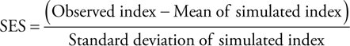

### Habitat filtering effect: the multivariate analysis of the environment

We tested whether the ant community composition was affected by the spatial position of the sampled trees (space effect). We used principal coordinates of neighbour matrices (PCNM) with distance‐based Moran's Eigenvector map (dbMEM) as a measure of the spatial effect (Legendre and Legendre 2012). We used a threshold consisting of including only one nearest neighbour (60 principal coordinates ordination (PCO) axes in total).

We ran five CCAs with interactive forward selection to test the role of habitat filtering and its possible correlation with the spatial distribution of trees on ant species composition. We separated the analyses into five different CCAs to reduce the ‘cases/variables' ratio. We tested the effects of the following predictors on the species distribution of Canopy ant community for each tree as a sample. First, we tested the effect of tree species identity on the distribution of arboreal ants. We used tree family/genus/species as predictors and only included those taxa with more than two tree individuals: CCA<sub>F</sub> tested tree family (18 families), CCA<sub>G</sub> tree genus (21 genera) and CCA<sub>S</sub> tree species (17 species). Next, CCA<sub>ENV</sub> covered other attributes of each sampled tree and forest‐plot topography with the tested variables: tree size (DBH of sampled tree in cm), elevation (in m a.s.l.), slope (in %), topography (convex/concave) and canopy connectivity.

With the Canopy ant community dataset, ant species that occurred on less than three trees (defined here as a rare species) were excluded from the multivariate analyses. We used a binominal data matrix (presence–absence) of each ant species on a tree (ant species × trees). Trees without any ants were also excluded from the analysis. The final data matrix was 119 trees × 13 ant species. In all CCAs, the explanatory variables were selected using forward selection (i.e. canonical correspondence analysis – constrained ordination type) with corrected p‐values (false‐discovery rate correction, 999 randomisations, α = 0.05). The efficiency of an axis was calculated as variability explained by the constrained axis divided by variability explained by the unconstrained axis.

We also consider the possibility that ant distribution is influenced by vegetation surrounding the tree where the baits were placed. As individual ant colonies can occupy multiple trees and ants often forage on multiple trees (Blüthgen et al. 2004, Dejean et al. 2015, 2019), it is possible that it is not just a single tree species that affects the ant species' distribution, but rather the sum of tree species of the whole forest site surrounding it. We created vegetation plots for each tree as a 10 × 10 m quadrat, with the sampled tree in the centre, to test if tree species composition surrounding the central tree significantly affects the composition of the ant community in it (i.e. if plant community has a direct impact on Canopy ant community). We included all trees in these quadrats with DBH > 10 cm from the Wanang CTFS‐ForestGEO forest plot database (Vincent et al. 2018) to characterise the surrounding vegetation. We then created a matrix of vegetation plots × all tree species in them, with values for each tree species representing a proportion of basal area (BA) of that tree species in total BA across all the tree species in that quadrat. We excluded all tree species whose sum BA was less than 1 m<sup>2</sup> across all the plots as rare. We then performed interactive forward selection CCA<sub>PLOT</sub> (with correction for false‐positives p) of the tree species (n = 89) to see if any tree species affects the species distribution of ants.

For graphical interpretation, we also calculated ant species response curves in CANOCO using a generalised linear model (GLM) for the continuous variables that showed a significant effect on ant species composition (i.e. elevation). The relationship (none, linear or polynomial) was selected using an F‐test. In addition, we plotted optimum and tolerance on the first CCA axis of each Ant arboreal community species. We calculated this for 1) CCA<sub>ENV</sub> constrained only by elevation and 2) CCA axis constrained by elevation with space as a covariate (calculated by PCNM). We rescaled all values back to metres.

### Competition effect: spatial segregation analysis

We limited our behavioural experiments and analysis to dominant species (Dominant ant community hereafter, Table 1), defined according to the abundance of workers at baits and the number of baits occupied as follows: for each tree, an ant species was considered as dominant if its total abundance on that tree was 1.5 times higher than any other species and if it occupied a majority of the ant‐visited baits. A bait was considered as occupied if there were at least 10 ant individuals on it. In cases where two or more species occupied a similar proportion of baits and were present in similar abundances, we assigned them all as dominants for the tree. Hence, we determined which ant species was numerically dominant in each tree individually, rather than using abundances in the whole plot. We used this quantitative approach as we did not wish to define the dominants using behavioural observations or literature data that are scarce for most of the species. Hence, it is possible that in some cases, the species might not be behaviourally dominant (Segev and Ziv 2012; e.g. here *Tapinoma melanocephalum* or *Polyrhachis* spp.).

First, we repeated the habitat filtering analysis (i.e. the five CCAs) using this Dominant ant community dataset to verify whether the same trends hold for the dominant and complete canopy ant communities. Next, this Dominant ant community dataset was further used for experimental tests of territorial boundaries within the 9‐ha plot in the field. We performed simple intraspecific behavioural tests on dominant species sampled from the study trees: we put workers from the two compared trees together into a ziplock bag (A4 size), observed their interaction for 10 min, and scored it as either attacking or not attacking each other. All workers at a bait were typically used for the confrontation, choosing the bait with the highest ant abundance for that tree. The test was used to determine whether the workers on two adjacent trees came from the same colony or not, based on the assumption that no aggression indicates a single colony that extends to multiple tree canopies. The result of such a test was typically clear within a few minutes, as ants attacked each other either viciously (expectation of different colonies) or tolerated each other (same colony). After we mapped the continuous territories of each colony using this approach, we also performed additional tests between distant trees (colonies) occupied by the same species, and confirmed the colony boundaries, or connected the territories, if no aggression occurred. Overall, we performed 184 behavioural tests (see an example in the Supporting information). Based on these tests, we were able to determine the boundaries of individual colonies for all dominant ant species in the 9‐ha area.

### Colony area null modelling algorithm

We developed a novel algorithm for the statistical tests of the ant mosaic: colony area null modelling algorithm (CANMA), which tests ant co‐occurrence, while not assuming spatial independency of sampled trees. The algorithm was developed to 1) allow reshuffling of the position of whole territories (individual canopy areas occupied by colonies) within the forest plot and 2) measure the amount of overlap among the species territories compared to a random simulation.

The dataset used for CANMA has rows as samples (trees) and columns as set variables: X and Y coordinates (in m), unique individual tree number code, dominant ant species code, unique code of colony and tree crown radius for each tree (in m, calculated from DBH; Supporting information). To create a spatial representation of species colonies in space, the algorithm first draws 10 points around each tree point at a distance of the crown's radius. These edge points are then connected to polygons by their unique colony code, each representing total space occupied by the given colony. We assume that all the area between two trees which are occupied by the same colony (including non‐sampled trees), is also occupied by that colony. It was only if there was a tree present inside the colony polygon area which was sampled but did not have the investigated species on it, that we excluded its area from the polygon. Note that this most parsimonious assumption in drawing the polygons across the trees which we did not sample, is likely to over‐estimate rather than under‐estimate the overlaps between territories, and hence decrease the chance of false positives (type I error). To prevent an edge effect in the spatial randomisation, we included only a subset of the observed polygons excluding data from the border of the plot. The distance from the edge to be excluded was set as the average radius from all colony polygons.

To create a null model of colony distribution, we randomised the position of each colony, calculated OI across all colonies (i.e. all pairwise overlaps between colonies), and compared it to the observed value. The position of each polygon was randomised and adjusted by the density of sampled trees in the focus area. The algorithm creates a new position for each centroid of each polygon skewed by the given density matrix (assuming that that there should be a lower chance of detecting an ant colony in places without trees). If no density matrix is given, then the position of the centroid would have been random. The polygon is rotated randomly (1–360 degrees) around the centroid. Each centroid is placed so the polygon fits into the whole observed area. This is repeated for all polygons (colonies).

After each randomisation (reshuffling and replacing of all polygons), the model separates the forest plot into two parts of the same area (Center and Trim; Supporting information) and calculates the sum of all polygons in each area. To prevent a mid‐domain effect, the model only considers the randomisation as ‘valid' if the sum of the area of all polygons in Trim is up to 1.5× the sum of the area of all polygons in Center. If this criterion is not fulfilled, the randomisation process is repeated (there were 150 741 runs for 10 000 valid randomised maps used for the model OI calculations in this study). OI of randomised polygons was calculated with the same border cutting as for the observed OI values.

The randomisation process was run 10 000 times as default, and the test scored as significant if observed OI was within the 5% quantile (we were testing if randomised OI is bigger than observed, one‐tailed test of the spatial over‐dispersion of the colony territories).

To investigate the stability of the results we also ran the algorithm with 1) a different number of randomisations (100, 1000, 10 000) and 2) different tree density maps (no density map, map of all big trees, map of only sampled trees). Individual p‐values were then compared (Supporting information).

### Spatially dominant species

In addition to testing the whole Dominant ant community, we compared the overlaps between each of the most dominant species and the rest of the species, using CANMA. We selected the four species that occupied the largest colony area when summed across the whole 9‐ha plot (Supporting information): *Crematogaster polita* (CREM 003), *Anonychomyrma* cf. *scrutator* (ANON 001), *Oecophylla smaragdina* (OECO 001) and *Podomyrma laevifrons* (PODO 001), hereafter Spatially dominant species. We recalculated OI but focusing only on a single species (CANMAs) and its territorial overlaps with all other species in the plot and compared the observed OI value to randomised values. We then calculated the SES as a measure of the species segregation from the rest of the canopy community for each of the four species.

### Aggression effect: behavioural segregation

We conducted a series of interspecies behaviour tests, using pair‐wise interactions among the four Spatially dominant species. The number of these combinations increases rapidly with the number of species, thus we limit our study to a modest number of species for logistic reasons. We selected nine independent colonies for each of three of the focal species (CREM 003, ANON 001, OECO 001), while we only found three colonies of sufficient size for PODO 001 for all tests. The same colony was used in up to three tests with colonies of other species, and only once for each species‐species combination (Supporting information). For each test, we sampled 10–20 workers from each colony and left them in a 100 ml clean plastic vial with cotton soaked in honey‐water over night to habituate. Five randomly selected individuals from each colony were then kept inside the vial that was joined via its opening with another vial with five individuals from another species. In this arena (Supporting information), a paired test between the two species was performed. We decided to use multiple individuals of each species in the test, as the ants build large colonies with many cooperative foragers, therefore a single worker test might have biased results.

To determine differences between species aggression, we created generalised linear mixed models via the template model builder (glmmTMB; *glmmTMB* package (Brooks et al. 2017)) with behavioural aggression of focal species (values of AI) as the dependent variable with a beta error distribution (link = logit, no zero‐inflation) and species as the independent variable. We compare species levels using a post hoc Tukey test. For more details about the test (Supporting information).

Next, we tested the correlation between behavioural aggression of focal species (values of AI) and their spatial segregation (SES values from CANMAs) using a glmmTMB model, with AI as the dependent variable with a beta error distribution (link = logit, no zero‐inflation) and SES as the independent variable. Finally, we created another glmmTMB model with AI as the dependent variable and AntBodySize as the independent variable to test if species aggression varies with body size. The mean head length (in mm) of each of the four ant species was used as the morphological trait that is regarded as a good proxy of ant body size (Gibb et al. 2018). The mean values were taken from the GLAD database (Parr et al. 2017) and rescaled to range between 0 and 1.

## Results

In total, 57 ant species from 20 genera were sampled (Fig. 1A). Of the 225 trees, 221 (98%) were occupied by ants (Table 1). The species composition differed between the strata below the canopy (< 10 m) and the canopy itself (> 10 m) (pseudo‐F = 6.5, p = 0.001). Individual species showed distinct vertical preferences so that the ant community was stratified from the trunk base to the top of the canopy (Fig. 1B).

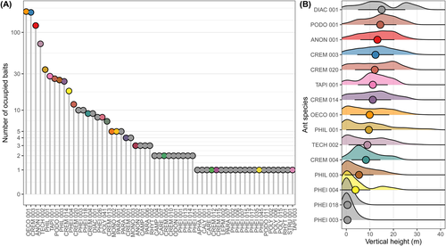

**Figure 1**

Distribution of ant species on 1127 tuna‐honey baits placed on 225 trees within a 9‐ha area of lowland primary forest in Papua New Guinea. Individual species are named by species codes, for full names see the Supporting information. Dominant species (defined in Material and methods) are colour‐coded. (A) Number of baits occupied by each ant species, ranked from the most to the least common species (57 species in total). (B) Vertical distribution of the 15 most common species that occur on more than 1% of the baits. For each species, we plotted the distribution of values, therefore, the area under the curve sums to 1. Circle with lines represents mean height ± SD.

Arboreal ant species displayed a strong segregation on the level of individual trees and the whole canopy communities, as they co‐occurred on the same tree less than expected at random (C‐score 39.2, p = 0.0001, SES = 6.27; Supporting information).

### Habitat filtering effect: multivariate analysis of the environment

Spatial distribution of trees (PCNM) explained 3.5% of the overall variance (28.5% efficiency of the first axes, Supporting information) in Canopy ant community composition, indicating spatial autocorrelation of the ant species distributions. From all tested environmental predictors, elevation was the only one in CCA<sub>ENV</sub> to have a significant effect on ant species composition within the plot (pseudo‐F = 4.9, p<sub>adj</sub> = 0.005, Supporting information) and it explained 2.0% of adjusted variability with 24.3% efficiency of the first axis.

Tree taxonomic identity (CCA<sub>F</sub>, CCA<sub>G</sub>, CCA<sub>S</sub>), as well as vegetation structure surrounding the sampled tree (CCA<sub>PLOT</sub>), did not show any significant effect on the ant species composition in the canopies (Supporting information).

CCA<sub>VAR</sub> explained 4.4% of adjusted variability in total with both elevation and space (PCNM). Variation partitioning among the two variables showed that elevation was responsible for only 20.5% of all explained variability while space was responsible for 55.2%, with 24.3% overlap among the two (Supporting information). Elevation was therefore correlated with space, but it still explained an independent part of the species composition after the reduction of spatial autocorrelation (0.9% of total variation). Species response curves to elevation showed a significant effect in seven of the 13 species tested (Supporting information). In particular, *C. polita* preferred lower, while *O. smaragdina* higher elevations (Supporting information).

When analyses were limited to Dominant ant community, the results did not change: the species significantly responded only to elevation (CCA<sub>ENV</sub>, pseudo‐F = 5.4, p<sub>adj</sub> = 0.005), while other environmental factors were not significant.

### Competition effect: spatial segregation analysis

Combining our bait samples with intraspecific aggression tests, we recognised 127 individual ant colonies of 23 dominant ant species in tree canopies, with an average size of 288.2 m<sup>2</sup> per colony (ranging from 29.3 m<sup>2</sup> for a number of species to a maximum of 6612.6 m<sup>2</sup> for *Crematogaster polita* (CREM 003)) (Supporting information).

CANMA showed significant spatial segregation of all species, with observed overlap index (OI) smaller than its mean value generated by randomisation (OI = 8.2, p = 0.0002, Fig. 2B). For comparison of CANMA and the C‐score calculated for the same datasets with various numbers of randomisations, Supporting information.

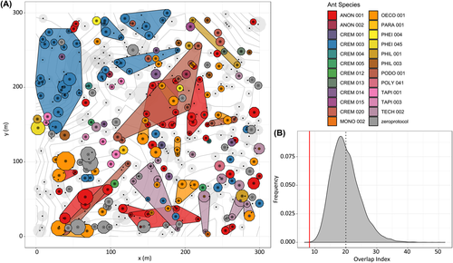

**Figure 2**

(A) Distribution of colony territories of dominant canopy ant species in a 9‐ha primary forest area in Papua New Guinea. Each dot is a high canopy tree (DBH ≥ 40 cm). The circle around each tree indicates its estimated canopy width (in m; Supporting information). Perimeters marked by black lines represent the trees sampled for canopy ants. Colony territory is drawn as a connection of canopy of trees occupied by the same colony. We assume that the area between trees occupied by the same colony, is also occupied by that colony. Grey contour lines indicate topography (detailed in the Supporting information). For full names of all species see the Supporting information. (B) Distribution of values of the overlap index generated by the canopy arena null modelling algorithm (CANMA) with 10 000 spatial randomisations of the territories. Dotted line shows mean simulated overlap index and red line shows observed overlap index value, which is significantly smaller than the mean of simulated values (CANMA: OI = 8.2, p = 0.0002). For a full description of CANMA, see Material and methods.

### Aggression effect: behavioural segregation

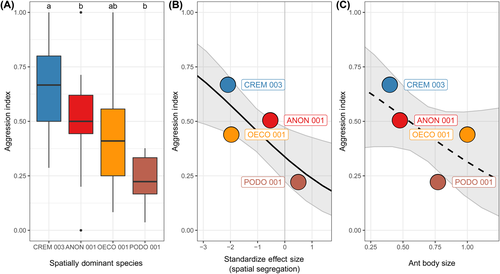

**Figure 3**

Aggression index (AI) based on a behavioural test between the top four Spatially dominant species (for full species names, see Methods and the Supporting information). Aggression index ranges from 0 (behavioural avoidance of contact with another species in an arena) to 1 (direct attack on another species). (A) Comparison of variability in AI between the four species (central bold lines indicate medians, boxes the 1st and 3rd quartiles, whiskers 1.5 times the interquartile range, and points are outliers). There is a significant effect of species (glmmTMB: χ<sup>2</sup> = 13.99; df = 3; p = 0.003). Differences between individual species are shown by different letters above the charts. (B) Relationship between AI of the four species and their spatial segregation, represented by standardised effect size (SES) of canopy arena null modelling algorithm (CANMA). There is a significant effect of a decline in species aggression with their decreasing spatial segregation (glmmTMB: χ<sup>2</sup> = 3.99; df = 3; p = 0.046). Negative SES shows strong species segregation from other species, values around zero represent random spatial overlap, and positive values show aggregation. (C) Relationship between AI of the four species and their body size (measured as the mean head length and rescaled to range between 0 and 1). There is no significant relationship between species aggression and body size (glmmTMB: χ<sup>2</sup> = 1.92; df = 3; p = 0.166).

We found a positive relationship between aggression (AI) and spatial segregation (SES) of the species from CANMA analysis (glmmTMB: χ<sup>2</sup> = 3.99; df = 3; p = 0.046), with more aggressive species being more spatially segregated from others (Fig. 3B). However, there was no significant correlation between AI and ant body size (glmmTMB: χ<sup>2</sup> = 1.92; df = 3; p = 0.166, Fig. 3C).

## Discussion

Ant mosaics, expressed as segregation of territorially dominant arboreal ants, have been found in primary lowland forests in Africa (Dejean et al. 2000, 2015), the Neotropics (Dejean et al. 2019), Borneo (Yusah et al. 2018, Law and Parr 2020) and Australia (Blüthgen and Stork 2007), and here we demonstrate their presence in a lowland forest of Papua New Guinea. Hence, there is increasing evidence that a highly non‐random distribution of ant species in tree canopies is typical not only for the less complex canopies of secondary forests and plantations, but also for primary forests.

Detection of spatial segregation of species distribution across space (plots) is still rarely used in ant ecology (but see Boulay et al. 2007) due to the difficulties of sampling in an inaccessible canopy of tropical forest. While most previous studies have been limited to individual isolated trees (Fayle et al. 2013, Yusah et al. 2018), here we demonstrate that mapping all dominant ant species and their territories is crucial and should cover a sufficiently large forest area and include a behavioural confirmation of colony boundaries. Such an approach is feasible, although it is time‐ and labour‐consuming. We suggest that accounting for spatial auto‐correlation (acknowledging non‐independence of trees), as done in our study, should be a standard of good practice in insect community ecology, as it is in plant ecology (Legendre and Fortin 1989).

The currently most used statistical test may not be the best tool for separating stochastic from non‐random processes and identifying their key drivers in ant communities. The C‐score is a common statistical tool for detecting ant mosaic patterns. It is a metric limited to the measurement of ant species coexistence within individual trees (samples) but neglects the spatial distribution of trees in the sampled area. The method also cannot accommodate the situation when a single colony occupies multiple trees (Leponce et al. 2021). This is problematic as the C‐score value can be the same for the community of two species occupying opposite sides of a plot (with almost no opportunity to compete) and two adjacent territories in two nearby trees, as soon as they do not occupy the same trees. Therefore, the use of this analytical approach is inappropriate for spatially dependent datasets (for large plots in particular), as it assumes the spatial independence of samples (trees).

The new randomisation algorithm presented in this study, allows us to use the colony territories (i.e. not only species records) in a null modelling approach to test for the presence of ant mosaics in 2‐D space. Since the bait‐line method provides information on the vertical distribution of colonies in trees, the next step could be to develop a 3‐D space approach, as it is possible that some of the species might mix their territories between tree trunks and canopies, or between small and large trees within the same local forest site (Leponce et al. 2021). The CANMA approach, combined with multivariable analyses, allows us to rigorously test for the non‐random spatial segregation of species that signifies ant mosaics, while also assessing the effects of environmental drivers (plot topography and vegetation) potentially important for ant distribution.

We acknowledge that our sampling methods and the CANMA algorithm also have some limitations. First, the algorithm is suitable for very large plots with multiple species territories, which calls for greater usage of a rapid‐assessment sampling method (e.g. baits) than methods more suitable for complete species sampling, via, for example, canopy fogging or felling (Ryder Wilkie et al. 2010, Klimes et al. 2015). As a result of this limitation, the sampling of rare and behaviourally submissive species (a significant part of ant diversity in canopies) is underestimated, and for those species the colony extensions might not have been possible to map. This decreases the likeliness of revealing positive ant mosaic relationships between some of the dominant and subdominant species (i.e. parabiosis; Menzel and Blüthgen 2010, Mottl et al. 2020). Further, the CANMA model might not be suitable for small plots, or datasets sampled across a variety of tree sizes (understorey and canopy), as individual crowns overlap in the 2‐D maps (Volf et al. 2019, Leponce et al. 2021). Finally, sampling only during the day in this study could lower the segregation of some species if sampling happens at different times (Yusah et al. 2018). However, data from our other project conducted in the same area suggest that even though there might be minor shift in ant species composition at bait activity, the main dominants (*Crematogaster polita*; CREM 003) are active both at day and night (Supporting information). Moreover, some of the above limitations hold also for C‐scores, whose results are highly dependent on what plot‐size and what part of an ant community is being considered (Leponce et al. 2021).

The ant mosaic theory, and the evidence of patterns‐only based sampling (Majer 1972, Camarota et al. 2016), proposes that canopy ant mosaics are driven mainly by species aggressive behaviour. This study is, to our knowledge, the first evidence using spatial modelling and intra‐ and interspecies behavioural experiments to support ant mosaic theory for a pristine high canopy. Although our interspecies tests are limited to only four of the most common species in the communities (n = 4), we found the significant correlation of the interspecies aggression index with the rate of their spatial mutual segregation (measured as SES from CANMA model). Even with such a low replication, the results showed that the spatially most dominant species (*C. polita*; CREM 003) is also the most aggressive species in the community. Interestingly, the results of the interspecies behavioural experiment were not related to the species body size: while *C. polita* (CREM 003) and *A.* cf. *scrutator* (ANON 001) were of much smaller body size than *P. laevifrons* (PODO 001) and *O. smaragdina* (OECO 001), the latter species being well known as an aggressive and territorial species (Hölldobler and Lumsden 1980), these smaller ants were still more aggressive in our experimental battles. As we studied primary forest and all four of the most dominant species are native to the region, these results are not biased by an invasive species or habitat degradation, which may affect ant species' distributions and the interspecies interactions in the forest, and thus ant mosaics (Sanders et al. 2003, Pfeiffer et al. 2008, Fayle et al. 2013). Indeed, in a recent study, Leponce et al. (2021) show that similar spatial patterns are common in New Guinea canopies across a series of smaller (0.3 ha) primary forest plots.

While other studies have reported the effect of habitat filtering on the composition of dominant ants through ant preference for certain tree families or species (Dejean et al. 2015, 2016, 2019), we were not able to detect any effect of tree taxonomy on our community of arboreal ants. However, as those previous studies draw conclusions without any statistical randomisation test (only observation of clustering of samples based on similarities) and include rare taxa, their results may be biased, making direct comparisons to our study difficult. Even though trees themselves are non‐randomly distributed in our study area, and their species and growth forms follow environmental gradients (Vincent et al. 2018), we do not find a strong effect of habitat filtering in our study, with the exception of elevation.

Even though our results show only a small effect of elevation on composition of ant communities, these results are relatively robust, with elevation being significant for both Canopy ant community and Dominant ant community. The effect of habitat filtering through changes in elevation is well‐studied (Fisher 1996, Staab et al. 2014) but rarely over such a small scale (elevation change in our system is only ~100 m). Our result could be an effect of general terrain‐related changes in microclimate since the terrain features of individual subplots are correlated to each other (Supporting information). Interestingly, changes in topography of the 50‐ha CTFS‐ForestGEO plot in PNG also affected the composition of tree (Vincent et al. 2018) and bird communities (Chmel 2017). One explanation is that changes in topography disturb the closed canopy and allow more light to access some parts of the trees. This higher sun intake could then increase the quality of resources and subsequently composition of canopy arthropods, such as ants (Philpott and Foster 2005).

Another aspect of specific ant reproduction is relatedness of colonies, with two colonies being potentially so genetically close that it is not possible to distinguish whether the workers are from the same colony or not (unicoloniality). We probably have an example of this in our study with *Podomyrma laevifrons* (PODO 001) being unaggressive but having the second biggest territory in our plot. This colony has different nests far apart from each other with a low possibility of exchange in individuals between the distant trees, yet workers were unable to distinguish between the populations. As the species prefers to nest in living tree tissue (Klimes 2017), its queens might establish new colonies over longer distances in order to reach young trees, compared to other dominant species. More information about the ecology of species and/or cuticular hydrocarbons (Mathis et al. 2016) is therefore needed to test the hypothesis of one or multiple colonies.

In summary, ant mosaics, expressed as spatial segregation of territorially dominant arboreal ants, are likely present in primary lowland rainforest all over the world, and species assembly of such arboreal ant communities is always a combination of behavioural traits, habitat filtering and dispersal possibilities that are difficult to disentangle. Our study provides evidence of the aggressive behaviour of several dominant species being a key driver, accompanied by habitat filtering via microclimate mediated by elevational variance. Determining such drivers of spatial distribution of omnipresent dominant ants will help us to better understand the ecological mechanisms governing tropical canopies. In addition to the ecological theory, the understanding of drivers of spatial distribution of super‐dominant ants (here *C. polita* and *O. smaragdina*) and their co‐existence with other ants, is of particular interest, as they are known to exhibit a high predation pressure and utilise many canopy resources (Richard et al. 2001, Blüthgen et al. 2004).

### Data availability statement

Data are available from the Zenodo Digital Repository <https://zenodo.org/record/4643701#.YGQY9K8zaUk> (Mottl et al. 2021).

*Acknowledgements* – We are grateful to the Wanang community and the Wanang Conservation Area for permission to use their land and for their logistic support during the project. We thank Pavel Fibich for providing code for calculating canopy width (Supporting information), and general advice on spatial ecology. We also thank Tom M. Fayle and Nicholas J. Gotelli for consultation of the randomisation process in CANMA. We thank the New Guinea Binatang Research Center (NGBRC) for all assistance during field sampling and preparing samples.

*Funding* – This study was supported by the Czech Science Foundation (21‐00828S), European Research Council (669609), Czech Academy of Sciences and Belgian Fund for Scientific Research (Research Mobility Plus Project FNRS‐17‐04) and University of South Bohemia Grant Agency (152/2016/P, 038/2019/P).

*Permit(s)* – Permits to export the collected insect samples from PNG to Czech Republic (no: 16208) were provided to the Biology Centre of Czech Academy of Sciences (CAS) by the Conservation and Environment Protection Agency of the PNG Government.

### Author contributions

**Ondřej Mottl**: Conceptualization (lead); Data curation (lead); Formal analysis (lead); Funding acquisition (supporting); Investigation (lead); Methodology (lead); Project administration (supporting); Software (lead); Visualization (lead); Writing – original draft (lead); Writing – review and editing (lead). **Jacob Yombai**: Data curation (equal); Investigation (equal); Writing – review and editing (supporting). **Vojtech Novotny**: Conceptualization (equal); Funding acquisition (lead); Methodology (supporting); Project administration (supporting); Resources (equal); Supervision (equal); Validation (supporting); Writing – review and editing (equal). **Maurice Leponce**: Conceptualization (supporting); Funding acquisition (supporting); Methodology (supporting); Validation (supporting); Writing – review and editing (equal). **George D. Weiblen**: Data curation (supporting); Resources (supporting); Writing – review and editing (supporting). **Petr Klimeš**: Conceptualization (equal); Funding acquisition (equal); Methodology (supporting); Project administration (equal); Resources (supporting); Supervision (lead); Validation (supporting); Writing – original draft (supporting); Writing – review and editing (equal).

[figure not shown]

[Early View](https://onlinelibrary.wiley.com/toc/16000706/0/0)

Online Version of Record before inclusion in an issue

### Details

© 2021 Nordic Society Oikos. Published by John Wiley & Sons Ltd

This is an open access article under the terms of the [Creative Commons Attribution](http://creativecommons.org/licenses/by/3.0/) License, which permits use, distribution and reproduction in any medium, provided the original work is properly cited.

### Keywords

- [ant mosaic](https://onlinelibrary.wiley.com/action/doSearch?field1=Keyword&text1=ant%20mosaic)
- [arboreal ant territories](https://onlinelibrary.wiley.com/action/doSearch?field1=Keyword&text1=arboreal%20ant%20territories)
- [community ecology](https://onlinelibrary.wiley.com/action/doSearch?field1=Keyword&text1=community%20ecology)
- competition
- [null models](https://onlinelibrary.wiley.com/action/doSearch?field1=Keyword&text1=null%20models)
- [spatial co-occurrence patterns](https://onlinelibrary.wiley.com/action/doSearch?field1=Keyword&text1=spatial%20co-occurrence%20patterns)
- [tropical forests](https://onlinelibrary.wiley.com/action/doSearch?field1=Keyword&text1=tropical%20forests)

### Publication History

- Version of Record online: 23 April 2021
- Manuscript accepted: 17 March 2021